# Tvyal Newsletter

Aghasi Tavadyan

2023-10-16

*English summary below.*

Հարգելի գործընկեր,

Հուսով եմ լավ եք: Ներկայացնում եմ անցած շաբաթվա վերլուծությունները և աշխատանքները.

1. Ռուսական ռուբլին ամրանալու է։ Արտարժույթի հնարավոր հոսքը Ռուսատանից Հայաստան
2. Միջազգային դրամական փոխանցումների վերլուծություն
3. ԶԼՄ հաղորդակցություններ, Բենզինի գին
4. English summary

## 1. Ռուսական ռուբլին ամրանալու է։ Արտարժույթի հնարավոր հոսքը Ռուսատանից Հայաստան

🔵➡️ Մեծ հավանականությամբ ռուբլին ամրանալու է։

🔵➡️ Հնարավոր է որ կապիտալի (դոլարի) ներհոսք ենք տեսնելու Ռուսաստանից Հայաստան։

Ռուսատանի Դաշնությունում 3 օր առաջ սահմանափակեց որոշ խոշորագույն արտահանողների կապիտալը։

Այս արտահանողներից կպահանջվի արտարժույթով ստացված եկամուտների ոչ պակաս, քան 80% ավանդադրել ռուսական բանկերում, այնուհետև երկու շաբաթվա ընթացքում վաճառել այդ հասույթի առնվազն 90% ներքին շուկայում: Այսինքն արտահանողները պիտք է արտարժույթով ստացած եկամուտի 75% ռուբլի սարքեն շուկայում։ Ավելին՝ [reuters.com](https://www.reuters.com/markets/europe/russian-government-sets-out-capital-control-rules-undisclosed-exporters-2023-10-13/):

Այս քայլը մեծացնելու է արտարժույթի քանակությունը ՌԴ շուկայում ու ամրացնելու է ռուբլին։ Անցած տարի այս ժամանակ դոլարը մոտ 60 ռուբլի էր 1 դոլարի դիմաց։ Վերջին 2 ամսվա ընթացքում 1 դոլարը հատել է 100 ռուբլի սահամնը մի քանի անգամ։

Սա է հանդիսացել հիմնական պատճառը որ Ռուսաստանում հիմնական տոկոսադրույքը բարձրացրել 7.5-ից 13% 2 ամսվա ընթացքում։ [Ավելին իմ կայքում](https://www.tvyal.com/newsletter/2023_10_03)։

Քանի որ այս քայլից դոլարի քանակությունը մեծանալու է Ռուսական շուկայում կարող ենք սպասել, որ ռուբլին 2-3 ամսվա մեջ ամրանալու է մինչև 1 դոլարը մոտ 88-92 ռուբլու, որից հետո այն ամենայն հավանականությամբ նորից սկսելու է հետ արժեզրկվել։ Սա առաջին հետևությունն է։

Երկրորդ հետևությունը այն է, որ այս պահին սահմանափակված ՌԴ խոշոր բիզնեսը կարող է ման գալ այլ երկրներ իր կապիտալ գործունեություն համար։

Այժմ մենք կարող է տեսնենք ՌԴ-ից կապիտալի 2-րդ արտահոսքը, ինչ տեսանք 2022 թ․ կեսերին։ Այս արտահոսքը ավելի ցածր կլինի քան նախորդը։ Սակայն մեր տնտեսական ցուցանիշները այս պահին գտնվում են անկման մեջ և եթե այս սցենարը իրականանա սա կլինի հավելյալ խթան մեր տնտեսության ու բանկային համկարգի համար։

## 2. Միջազգային դրամական փոխանցումների վերլուծություն

2022 թվականն աննախադեպ տարի էր ֆիզիկական անձանցից դեպի հայկական բանկեր բանկային փոխանցումների աճի առումով, դրանք աճել են 2,5 անգամ՝ 2,1 մլրդ դոլարից հասնելով 5,2 մլրդ դոլարի։ Այս աճը հիմնականում պայմանավորված է Ռուսաստանից ստացված բանկային փոխանցումներով, որոնք քառապատկվել են՝ 865 մլն դոլարից հասնելով 3,6 մլրդ դոլարի։ Արդյունքում Հայաստան է փոխանցվել զգալի գումար՝ հիմնականում դոլարով, ինչը հանգեցրել է դոլարի առաջարկի աճին և դոլարի արժեզրկմանը դրամի նկատմամբ (տես գծապատկեր 1.)։ Տնտեսական գործոնները խիստ փոխկապակցված են: 2022 թվականին արտարժույթի ներհոսքը բանկային համակարգ աճել է 2,5 անգամ, իսկ արտահոսքը՝ մոտ 2 անգամ։ 2022 թվականին ներհոսքը կազմել է 5,2 մլրդ դոլար, իսկ արտահոսքը՝ 2,7 մլրդ դոլար։

*Գծապատկեր 1.* ՀՀ բանկային համակարգի միջոցով կատարված դրամական փոխանցումներ (տարեկան, մլրդ դոլար)։

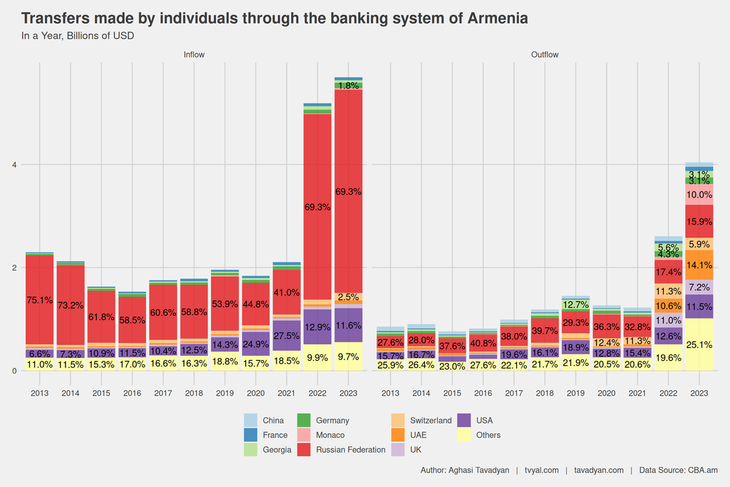

*Գծապատկեր 2.* ՀՀ բանկային համակարգի միջոցով կատարված դրամական փոխանցումներ (12 ամսվա կտրվածքով, մլրդ ԱՄՆ դոլար)։

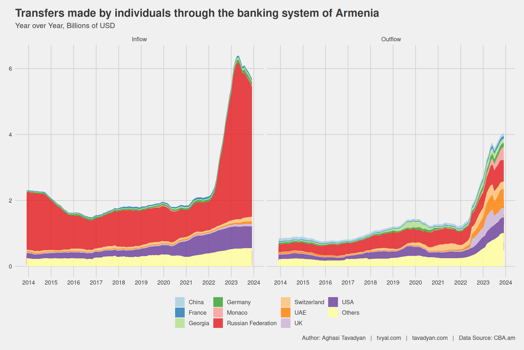

*Գծապատկեր 3.* ՀՀ բանկային համակարգի միջոցով կատարված դրամական փոխանցումներ (ամսական կտրվածքով, մլն ԱՄՆ դոլար)։

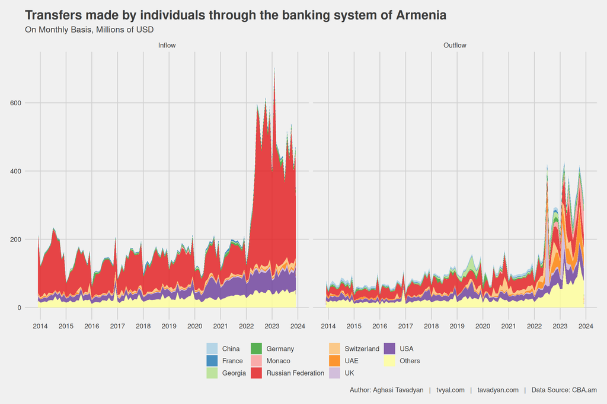

Քանի որ բանկային փոխանցումների մոտ 70 տոկոսը գալիս է Ռուսաստանի դաշնությունից, դիտարկենք նաև առանձին ՌԴ-ից կատարված բանկային փոխանցումները

*Գծապատկեր 4.* Ռուսատանից ստացված ոչ կեմերցիոն և ընդհանուր բանկային փոխանցումները (ամսական կտրվածքով, մլն ԱՄՆ դոլար)։

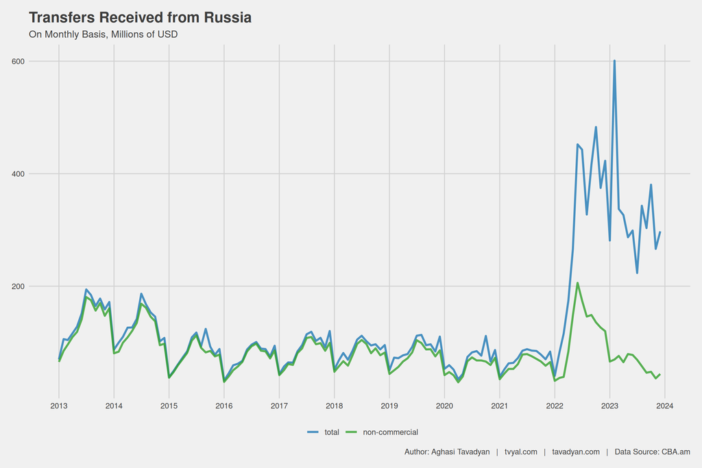

Ինչպես երևում է գծապատկերից մինչև 2022 թվականը փոխանցումների գերակշիռ մասը ոչ կոմերցիոն բնույթի տրանսֆերտներն էին, 2022 թվականից սկսած գերակշիռ մասը փոխանցումների ուներ կոմերցիոն բնույթ։ Նշեմ նաև որ ոչ կոմերցիոն տրանսֆերտների / ՀՆԱ հարաբերությունը անկում է ապրել և այս պահին ռեկորդային ցածր 8 տոկոսի մակարդակի վրա է։

## 3. ԶԼՄ հաղորդակցություններ, Բենզինի գին

Բենզինի գնի հարցի լուծումն ավելի շատ քաղաքական է.

[Կարդացեք իմ նոր հարցազրույցը](https://www.panorama.am/am/news/2023/10/10/%D4%B1%D5%B2%D5%A1%D5%BD%D5%AB-%D4%B9%D5%A1%D5%BE%D5%A1%D5%A4%D5%B5%D5%A1%D5%B6/2909640)։

- Մեկ տարում բենզինի գինը 380 դրամից հասել է 580 դրամի մեկ լիտրի դիմաց։ Վերջին աճը կապված է դրամի արժեզրկման և նավթի համաշխարհային շուկայի դինամիկայի հետ: Քանի որ դրամը նույնպես տատանվում էր՝ բենզինի գները բարձրացնելով։
- Համաշխարհային գործոնները, ինչպիսիք են ՕՊԵԿ+ նավթի արդյունահանման սահմանափակումները, նույնպես ազդում են գների վրա։ Չնայած ցածր պահանջարկին, առաջարկի արհեստական սահմանափակումները գները բարձր են պահում: Իրավիճակին նպաստում է նաև Ռուսաստանի կողմից բենզինի արտահանման վերջին էմբարգոն։
- Ռուսաստանի պայքարը ռուբլու արժեզրկման և նավթի արտահանման դեմ հանգեցրել է բենզինի ներքին դեֆիցիտի, որը ազդել է նաև մեր շուկայի վրա։

[Այս խնդրի մասին ավելին տեղեկանալու համար կարդացեք հարցազրույցը](https://www.panorama.am/am/news/2023/10/10/%D4%B1%D5%B2%D5%A1%D5%BD%D5%AB-%D4%B9%D5%A1%D5%BE%D5%A1%D5%A4%D5%B5%D5%A1%D5%B6/2909640)

## 4. English Summary

1. The Russian ruble is expected to strengthen due to recent capital control measures imposed by the Russian government on exporters. These measures require exporters to deposit a significant portion of their foreign currency earnings in Russian banks and sell most of their earnings on the domestic market. This will increase the amount of foreign currency in the Russian market, strengthening the ruble. As a result, it is anticipated that the ruble will strengthen to 88-92 rubles per dollar in the next 2-3 months, followed by a potential depreciation. This could lead to an outflow of capital from Russia, benefiting Armenia’s economy and banking system.
2. In 2022, Armenia experienced a substantial increase in international money transfers, particularly from Russia, resulting in an influx of dollars into the country’s banking system. The significant inflow of foreign currency was coupled with a rise in outflows. This dynamic has been instrumental in influencing the exchange rate of the Armenian dram against the US dollar.
3. A portion of the report discusses the rising gasoline prices in Armenia, which have increased significantly over the past year. Factors contributing to this increase include the devaluation of the dram, global oil market dynamics, OPEC+ oil production restrictions, and Russia’s export embargo on gasoline, leading to internal shortages in Armenia. The rising gasoline prices are seen as a political issue with global and domestic implications.

Այս վերլուծությունը առկա է նաև [մեր կայքեջում](https://www.tvyal.com/newsletter/2023_10_16), այս վերլուծության կոդը դրված է նաև [Github-ում](https://github.com/tavad/tvyal_newsletter)։

Եթե հնարավոր է, խնդրում եմ այս նյութը ուղարկել նաև այն մարդկանց, ում այն կարծում եք կարող է հետաքրքրել:

Սպասեք հաջորդ հաղորդագրությանը մի շաբաթվա ընթացքում:

Հարգանքներով,  
Աղասի Թավադյան  
16.10.2023  
[tvyal.com](https://www.tvyal.com/)  
[tavadyan.com](https://www.tavadyan.com/)

**Ուշադրություն. Ձեր էլ.փոստը մեյլիսթի մեջ է, որի միջոցով ես կիսվում եմ շաբաթական նյութեր, որոնք հիմնականում ներկայացնում են Հայաստանի տնտեսությանը: Նյութերը ներառում են գծապատկերներ, [տվյալների բազաներ](https://github.com/tavad/tvyal_newsletter), տեսանյութեր, հոդվածներ, [առցանց վահանակներ](https://www.tvyal.com/projects), տնտեսական գործիքներ, կանխատեսումներ և հաշվետվություններ: Եթե ցանկանում եք չեղարկել բաժանորդագրությունը, խնդրում եմ տեղեկացրեք ինձ, և ես կհեռացնեմ ձեր էլ. փոստը ցուցակից: Գրեք նաև եթե ունեք մենկնաբանություններ:**

**Important! Your email is part of the mailing list where I share weekly materials primarily focused on the Armenian economy. These materials encompass charts, [databases](https://github.com/tavad/tvyal_newsletter), videos, articles, [online dashboards](https://www.tvyal.com/projects), economic tools, forecasts, and reports. If you wish to unsubscribe, please let me know, and I will remove your email from the list. Please share your comments as well․**